# Hedonic Regression: Does the Property Market Price Climate Risk and Resilience?

Dave Schaaf, Chris Clever, Neeraj Athani

May 2026

## Overview

Descriptive cross-county hedonic regression of Zillow Home Value Index (ZHVI) on FEMA National Risk Index (NRI) components, controlling for ACS demographics and state + month fixed effects. The goal is to document whether higher climate risk and lower community resilience are associated with lower property values, conditional on observables.

This is a **descriptive correlation**, not a causal estimate. Coastal amenity confounds the risk signal at the county level even with the controls included here. The event study (notebook `05`) is the complementary causal analysis.

## 1. Setup

## 2. Load Python-prepped panel

```
## Rows:                188,925
```

```
## Counties:            3064
```

```
## Months:              62
```

```
## Window:              2020-11-01 to 2025-12-01
```

```
## Coastal counties:    458
```

[output not shown]

```
##       stcofips          state     stateabbrv         county          month
##              0              0              0              0              0
##       month_id           year      month_num    nri_vintage cdc_svi_regime
##              0              0              0              0              0
##           zhvi       eal_valt     risk_value      crf_value     resl_value
##              0              0              0              0              0
##     resl_score     sovi_score     sovi_value     population           area
##              0              0         104100              0              0
##    pop_density        coastal
##              0              0
```

## 3. Pull ACS controls and USDA urban/rural designation

We need county-level controls that the NRI components don’t already capture:

- **Median household income** - the largest non-NRI driver of housing value
- **Coastal County Status** - account for coastal amenity and/or risk

Considered but left off due to overlap with community resilience and social vulnerability calculations: - **Share with bachelor’s degree+** - human capital, picks up labor market quality - **Share owner-occupied** - tenure mix shifts price dynamics - **Median age** - lifecycle/retiree composition, related to migration patterns - **Median year structure built** - housing stock vintage, captures durability

We deliberately do *not* pull poverty, vehicle access, household size, or disability share - those are inputs to the CDC SVI and would create multicollinearity with `sovi_score`.

[output not shown]

```
##    stcofips         median_hh_income share_bach_plus  share_owner_occ
##  Length:3220        Min.   : 16170   Min.   :0.0000   Min.   :0.0000
##  Class :character   1st Qu.: 54113   1st Qu.:0.1709   1st Qu.:0.6874
##  Mode  :character   Median : 63162   Median :0.2153   Median :0.7432
##                     Mean   : 65047   Mean   :0.2410   Mean   :0.7296
##                     3rd Qu.: 73216   3rd Qu.:0.2869   3rd Qu.:0.7860
##                     Max.   :178707   Max.   :0.7973   Max.   :0.9739
##    median_age    median_yr_built
##  Min.   :21.40   Min.   :1938
##  1st Qu.:38.80   1st Qu.:1971
##  Median :41.50   Median :1979
##  Mean   :41.81   Mean   :1978
##  3rd Qu.:44.60   3rd Qu.:1985
##  Max.   :68.90   Max.   :2010
```

## 4. Merge and finalize variables

```
## Final analytic rows: 188,925
```

```
## Counties:            3064
```

```
## # A tibble: 9 × 5
##   rucc_2023 n_counties mean_resl mean_zhvi mean_income
##       <int>      <int>     <dbl>     <dbl>       <dbl>
## 1         1        441      2.78   303410.      87303.
## 2         2        378      2.77   220777.      70520.
## 3         3        356      2.77   207636.      67726.
## 4         4        199      2.76   192019.      63311.
## 5         5         76      2.72   216322.      65033.
## 6         6        379      2.73   169515.      60247.
## 7         7        246      2.71   188143.      60482.
## 8         8        457      2.68   160811.      58557.
## 9         9        532      2.69   155449.      58620.
```

## 5. Model specifications

```
##                                             mA                mB
## Dependent Var.:                       log_zhvi          log_zhvi
##
## log_eal                         -0.007 (0.006)    -0.002 (0.006)
## log_crf                         -0.010 (0.029)
## log_income                     1.13*** (0.035)   1.13*** (0.034)
## log_pop_density               0.053*** (0.006)  0.058*** (0.006)
## coastal                       0.061*** (0.014)  0.073*** (0.014)
## resl_value_z                                   -0.056*** (0.009)
## sovi_score_z                                   -0.024*** (0.005)
## sovi_score_z x cdc_svi_regime
## Fixed-Effects:                ---------------- -----------------
## state                                      Yes               Yes
## month_id                                   Yes               Yes
## factor(rucc_2023)                           No                No
## _____________________________ ________________ _________________
## S.E.: Clustered                   by: stcofips      by: stcofips
## Observations                           188,925           188,925
## R2                                     0.76876           0.77276
## Within Adj. R2                         0.57452           0.58188
##
##                                              mC                mD
## Dependent Var.:                        log_zhvi          log_zhvi
##
## log_eal                          -0.003 (0.006)    -0.005 (0.006)
## log_crf
## log_income                      1.14*** (0.034)   1.20*** (0.028)
## log_pop_density                0.058*** (0.006)  0.056*** (0.006)
## coastal                        0.073*** (0.014)  0.069*** (0.014)
## resl_value_z                  -0.056*** (0.008) -0.052*** (0.009)
## sovi_score_z                    -0.015* (0.007)
## sovi_score_z x cdc_svi_regime  -0.010** (0.004)
## Fixed-Effects:                ----------------- -----------------
## state                                       Yes               Yes
## month_id                                    Yes               Yes
## factor(rucc_2023)                            No                No
## _____________________________ _________________ _________________
## S.E.: Clustered                    by: stcofips      by: stcofips
## Observations                            188,925           188,925
## R2                                      0.77282           0.77178
```

[output cut: 9 more lines]

```
## coastal                        0.113*** (0.018)  0.075*** (0.014)
## resl_value_z                      0.012 (0.009) -0.059*** (0.009)
## sovi_score_z                  -0.162*** (0.005) -0.024*** (0.005)
## sovi_score_z x cdc_svi_regime
## Fixed-Effects:                ----------------- -----------------
## state                                       Yes               Yes
## month_id                                    Yes               Yes
## factor(rucc_2023)                            No               Yes
## _____________________________ _________________ _________________
## S.E.: Clustered                    by: stcofips      by: stcofips
## Observations                            188,925           188,925
## R2                                      0.67072           0.77385
## Within Adj. R2                          0.39414           0.43227
## ---
## Signif. codes: 0 '***' 0.001 '**' 0.01 '*' 0.05 '.' 0.1 ' ' 1
```

```
##                                  mB                mF
##                             No RUCC           RUCC FE
## Dependent Var.:            log_zhvi          log_zhvi
##
## log_eal              -0.002 (0.006)    -0.003 (0.006)
## resl_value_z      -0.056*** (0.009) -0.059*** (0.009)
## sovi_score_z      -0.024*** (0.005) -0.024*** (0.005)
## log_income          1.13*** (0.034)   1.13*** (0.038)
## log_pop_density    0.058*** (0.006)  0.053*** (0.006)
## coastal            0.073*** (0.014)  0.075*** (0.014)
## Fixed-Effects:    ----------------- -----------------
## state                           Yes               Yes
## month_id                        Yes               Yes
## factor(rucc_2023)                No               Yes
## _________________ _________________ _________________
## S.E.: Clustered        by: stcofips      by: stcofips
## Observations                188,925           188,925
## R2                          0.77276           0.77385
## Within R2                   0.58189           0.43229
## ---
## Signif. codes: 0 '***' 0.001 '**' 0.01 '*' 0.05 '.' 0.1 ' ' 1
```

## 6. Interpretation guide

For continuous logged predictors (`log_eal`, `log_crf`, `log_income`, `log_pop_density`): each coefficient is approximately the percent change in ZHVI per 1% change in the predictor (elasticity).

For standardized predictors (`resl_value_z`, `sovi_score_z`): coefficients are the percent change in ZHVI per **1 standard deviation** increase in the predictor.

For the binary `coastal` and the `share_*` and `median_age` controls: coefficients are percent change in ZHVI per unit change.

**Expected directions if markets price climate risk and resilience:**

- `log_eal` < 0: higher expected losses → lower prices
- `log_crf` < 0: higher community risk factor → lower prices
- `resl_value_z` > 0: more resilient community → higher prices
- `sovi_score_z` likely < 0 but interpretation is mostly about the population, not climate
- `coastal` > 0 (and probably large): the amenity premium swamps the risk discount in raw form

The regime-interaction term in Spec C tests whether the SoVI coefficient shifts when the underlying SoVI methodology changes. A large, significant interaction means we can’t interpret the pooled SoVI coefficient cleanly.

## 7. Robustness

```
##                                mB         m_nocoast   m_state_cluster
##                              Main       Inland only     State cluster
## Dependent Var.:          log_zhvi          log_zhvi          log_zhvi
##
## log_eal            -0.002 (0.006)    -0.005 (0.007)    -0.002 (0.009)
## resl_value_z    -0.056*** (0.009) -0.059*** (0.009) -0.056*** (0.015)
## sovi_score_z    -0.024*** (0.005) -0.037*** (0.006)   -0.024* (0.010)
## log_income        1.13*** (0.034)   1.07*** (0.037)   1.13*** (0.072)
## log_pop_density  0.058*** (0.006)  0.068*** (0.007)  0.058*** (0.013)
## coastal          0.073*** (0.014)                      0.073* (0.031)
## Fixed-Effects:  ----------------- ----------------- -----------------
## state                         Yes               Yes               Yes
## month_id                      Yes               Yes               Yes
## _______________ _________________ _________________ _________________
## S.E.: Clustered      by: stcofips      by: stcofips         by: state
## Observations              188,925           160,547           188,925
## R2                        0.77276           0.73877           0.77276
##
##                       m_2023plus         m_pre2023
##                       CDC regime       HVRI regime
## Dependent Var.:         log_zhvi          log_zhvi
##
## log_eal            0.001 (0.007)  -0.016** (0.006)
## resl_value_z     -0.018. (0.010) -0.096*** (0.009)
## sovi_score_z     -0.014* (0.007)  -0.022** (0.007)
## log_income       1.12*** (0.039)   1.18*** (0.032)
## log_pop_density 0.054*** (0.007)  0.066*** (0.006)
## coastal         0.070*** (0.015)  0.069*** (0.013)
## Fixed-Effects:  ---------------- -----------------
## state                        Yes               Yes
## month_id                     Yes               Yes
## _______________ ________________ _________________
## S.E.: Clustered     by: stcofips      by: stcofips
## Observations             104,100            84,825
## R2                       0.76910           0.78368
## ---
## Signif. codes: 0 '***' 0.001 '**' 0.01 '*' 0.05 '.' 0.1 ' ' 1
```

## 8. Implied-discount-rate calibration (back-of-envelope)

If a 1% increase in expected annual loss reduces ZHVI by β₁ percent, then β₁ implies the market’s effective capitalization rate on hazard losses. Compare to a 5% benchmark (rough perpetuity discount on annual losses).

```
## β on log(EAL):                        -0.0025
```

```
## Implied $-discount per $ of annual EAL: 0
```

```
## Benchmark (5% rate, perpetuity):       -20.00
```

```
## Example:  -0.00016875
```

```
##
## If the implied figure is ~-20, the market is pricing risk near a 5% rate.
```

```
## If it's ~ -2, the market is pricing risk near a 50% rate (heavy discount).
```

```
## If it's near 0 or positive, the market is essentially ignoring risk.
```

## 9. Caveats and what this analysis cannot establish

This regression measures *correlation conditional on observables*. The county-level coastal dummy and ACS controls do not fully purge amenity bias (people pay more to live near oceans regardless of climate risk). The hedonic coefficient is therefore a **lower bound on the true risk discount in absolute terms** - the market may discount risk more than we measure, but the amenity premium is netting against it.

The SoVI methodology break in March 2023 means the pooled-sample SoVI coefficient mixes two different measurements. The regime-interaction term in Spec C and the stratified robustness checks test whether this matters in practice.

ZHVI is smoothed and seasonally adjusted. For the cross-sectional question this matters less than for the event study, but month-to-month price discovery is attenuated.

The event study (notebook `05`) provides a complementary, less amenity-confounded test of whether markets *update* when risk is realized via storm.

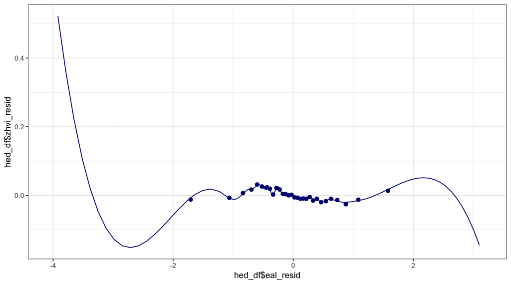

[output not shown]